# SRM Chapter 3.5

theBudgetActuary

# Data Transformations

Some transformations are necessary for the stability of our model, while other times transformations simply increase the interpretability of our model. In this section we will cover different data transformation options and when to apply them.

# Standardization

Standardization is one of the most commonly used data transformations. Standardization is the result of centering and then scaling the predictors.

## Centering

Centering is the process of finding the mean of each independent variable, and then subtracting the mean value from each of the observations in that variable. This sets the mean of each predictor to 0.

## Scaling

Scaling involves dividing each predictor by its standard deviation. After performing this, the standard deviation of each predictor becomes 1.

# Normalization

Normalization: $\frac{x_{i}-min(x)}{max(x)-min(x)}$

# Why Apply Data Transformations

## Linear Regression

### Centering

Centering should be applied to our predictors whenever additional predictors are created that are transformations of our original predictors. Examples would include whenever we add interaction terms or polynomial terms. If we do not center our independent variables before making these new predictors, multicollinearity could become a problem.

Below shows the effect of creating a polynomial term without centering and then with centering. Notice how the correlation changes with and without centering.

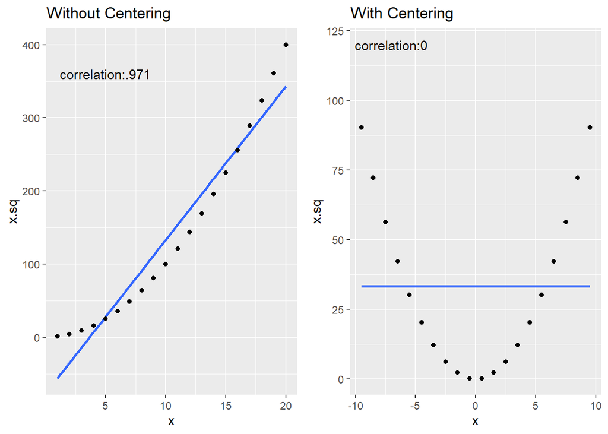

This is an exaggerated example, but you can see with centering the predictor before finding a polynomial term the correlation between the predictors greatly decreases. In this case it goes from .971 which is almost perfect correlation to a value of 0. This is because after the centering of the predictor it introduces negative terms which help break up the linear relationship between the two predictors.

Another reason centering should be applied to linear regression is give our intercept term a new interpretation. Before centering the intercept can be interpreted as the predicted value of y when all predictors are set to 0. This doesn’t make sense in some cases as you can end up with negative values. An example would be if predicting weight from height, a height of 0 could produce a negative weight.

After centering our predictors the interpretation of our intercept becomes the predicted value of y when all predictors are at their average values. So the interpretation would become the weight of a person for an average weight individual. (Goyal, 2021)

### How to Use a Centered Linear Regression Model

The only values that change after centering is the intercept coefficient value, the intercept standard error, and the intercept p-value. The predictors coefficients, standard errors, and p-values remain the same.

In order to make a prediction from our new model, instead of entering in the original values such as (x1=5, x2=4…) we instead subtract the mean from each of these values before entering them into the model. The entered observations would become x1=5-mean(x1), x2=4-mean(x2)… If we center the observations before we enter them into the model we will get the same predicted value and prediction intervals as our non-centered model.

### Scaling in Linear Regression

We found that if we center our predictors the intercept changes. If we scale our predictors the predictor coefficients change. This means their parameter estimates and standard errors change. However, their p-values remain the same. This means after scaling the predictors they still have the same effect on the dependent variable.

In order to make a prediction from this model we would divide the observations being entered by their respective standard deviation. So if we wanted to enter in the observation (x1=5,x2=5), we would enter in (x1=5/$sd_{x1}$, x2=5/$sd_{x2}$). This would produce the same predictions and prediction intervals as our non-scaled model.

### Standardizing Predictors in Linear Regression

If we standardize our predictors both the intercept and predictor coefficient values change. This includes all the parameter standard errors. However, their p-values again remain the same.

In order to make a prediction we have to standardize the observations being added to the model. This would mean observation (x1=5,x2=5) would be entered as x1=$\left(\frac{5-mean(x1)}{sd_{x1}} \right)$,x2=$\left(\frac{5-mean(x2)}{sd_{x2}} \right)$

### Standardizing Predictors and Dependent Variable in Linear Regression

The purpose of standardizing both the predictor variable as well as the dependent variable is that it puts all the predictors on a similar scale. The interpretation of our coefficient estimates is a one standard deviation increase in our $x_{1}$ parameter results in a $b_{1}$ standard deviation increase in our dependent variable.

Example: If our model after standardizing was $y=2+2(x1)+1(x2)$, we could say with a one standard deviation increase in x1, and holding x2 constant, we can expect a 2 standard deviation increase in the dependent variable y.

Standardizing the dependent variable will change our intercept and coefficient estimates and their standard errors. However, there p-values will still remain the same.

In order to make predictions from our standardized model on both sides of the equation we have to first enter in observations that have been standardized, just like when the model only used standardized predictors. Because our prediction will now be standardized we have to reverse our results to get them back into their original units. What I mean by this is that if we enter our standardized observations and get a prediction of 1.2, we can convert this back to original units by multiplying back the standard deviation of y, and then adding back the mean of y.

We would have to apply this same reverse transformation to our prediction intervals in order to get them back to the original units.

# Log(y)

We discussed last section that we can apply the natural log transformation to our dependent variable as a possible way to address heteroscedasticity. However, we did not address how to use this model in order to make predictions.

If we apply no type of scaling to our predictors we enter in the observations in their usual form. However, the prediction output will now be in the natural log form. In order to convert our prediction back to the original units we apply the reverse transformation which is:

Unscaled Value= $e^{Scaled\ Value}$

Unlike standardization methods like centering and scaling, the predicted value will not be the same when we apply a log transformation to our dependent. This is because transformation techniques effect the observations equally whether that is subtract by the same mean, or divide by the same standard deviation for each predictor. The log transformation affects higher values more and not on the same scale as smaller observations. This forces larger observations to be pushed closer together. (2022)

# Comparing log Transformation With Standardization Approaches for Linear Regression

For standardization approaches the statistical tests do not change for our predictors. This means they have the same predicting power in interpreting the dependent variable whether or not they are standardized. This produces the same $R^{2}$ value and p-values for coefficient estimates. Also, if observations are standardized accordingly before being entered in the model they will produce the same predictions as a non-standardized model.

When we apply a log transformation the predictions from our models change even if we apply transformations correctly. This means the significance of our predictors change as well as the $R^{2}$ value.

# KNN Standardization

When using KNN if the predictor values are on different scales they should be standardized before building the algorithm. This is because predictors on a bigger scale will have a larger effect on deciding which observations are closer compared to predictors on a smaller scale. An example would be if you were given the following data set:

| obs | x1 | x2 | y |
| --- | --- | --- | --- |
| 1 | 1 | 700 | 3 |
| 2 | 3 | 500 | 5 |
| 3 | 5 | 300 | 7 |
| 4 | 7 | 100 | 9 |

If given an observation of (x1=5,x2=300) and using k=3, the three nearest observations would be 2,3,and 4. If we randomly assigned our values in x1 to different values based on their scale of 1-7, the prediction would not change. If we randomly assigned the values in x2 to different values based on their scale of 100-700, it would drastically change the prediction. Standardization solves this problem by putting the predictors on the same scale.

#### Sources:

The Pennsylvania State University. (2022). 9.5 - more on transformations: Stat 501. PennState: Statistics Online Courses. Retrieved September 13, 2022, from https://online.stat.psu.edu/stat501/lesson/9/9.5

Goyal, C. (2021, March 30). Standardized and unstandardized regression coefficients. Analytics Vidhya. Retrieved September 13, 2022, from https://www.analyticsvidhya.com/blog/2021/03/standardized-vs-unstandardized-regression-coefficient/